# Efficacy and safety of cefepime: a meta-analysis

Luis Pinheiro

07/06/2019

## Meta-analysis in R

### Introduction

There are several packages to conduct meta-analyses in R. In fact, there is an entire **Task View** on CRAN dedicated to packages for meta-analyses. I use a few different packages when conducting/re-running meta-analyses in R, but mainly `meta` and `metafor` which are the ones I will be presenting.

The purpose of this presentation is to describe the tools available in R to conduct meta-analyses. I will not to go into detail on *how* to conduct a meta-analysis. Nevertheless, we will touch upon some issues of interpretation of meta-analyses.

The presentation is built in R Markdown. I will upload the code to the code</>club folder. You are welcomed to reuse the code.

### The systematic review

Certainly, the most time consuming part of conducting a meta-analyses is the identification and selection of studies to include and the collection of data.

I will not address this part of conducting a meta-analysis. However, there are packages in R such as `bibliometrix` and `metagear` that can assist in this part of the process.

### The data

The data used in this meta-analysis was collected from [Yahav et al, 2007](https://www.ncbi.nlm.nih.gov/pubmed/17448937). The Yahav meta-analysis suggests a risk of increased all-cause mortality in patients with febrile neutropenia taking cefepime as compared to other beta-lactams.

This signal was discussed at the Pharmacovigilance Working Party in 2010/2011. During the assessment EMA re-ran the Yahav et al meta-analysis but did not conduct an independent systematic review and meta-analysis. On the other hand, FDA conducted a new meta-analysis. The safety concern has been refuted.

```r
# Load libraries but suppress warnings and messages
suppressWarnings(suppressMessages(library(tidyverse)))
suppressWarnings(suppressMessages(library(meta)))
# Read the file with studies
papers <- suppressWarnings(suppressMessages(read_csv("data.csv")))
# See the data - in this case I will use the DT package for interactivity in my html output
suppressWarnings(suppressMessages(library(DT)))
papers %>%
      select(author, year, indication, severity_infections, comparator_drug, publication_type,
             cefepime_events_fatal, cefepime_total, comparator_events_fatal, comparator_total) %>%
      datatable()
```

|  | author | year | indication | severity_infections | comparator_drug | publication_type | cefepime_events_fatal | cefepime_total | comparator_events_fatal | comparator_total |
| --- | --- | --- | --- | --- | --- | --- | --- | --- | --- | --- |
| 1 | Aoun et al | 1997 | Neutropenic fever | severe | Ceftazidime | Unpublished | 5 | 54 | 3 | 57 |
| 2 | Aufiero et al | 1997 | Other and mixed infections | mild | Ceftazidime | Journal | 3 | 57 | 0 | 29 |
| 3 | Barckow and Schwigon | 1993 | Other and mixed infections | moderate | Cefotaxime | Journal | 13 | 41 | 4 | 21 |
| 4 | Beaucaire et al | 1999 | Pneumonia | moderate | Ceftazidime | Journal | 29 | 141 | 21 | 134 |
| 5 | Biron et al | 1998 | Neutropenic fever | moderate | Imipenem-cilastatin | Journal | 10 | 200 | 4 | 195 |
| 6 | Bohme et al | 1998 | Neutropenic fever | severe | Piperacillin-tazobactam | Journal | 2 | 49 | 2 | 51 |
| 7 | Bonfitto et al | 1999 | Pneumonia | moderate | Ceftazidime | Journal | 0 | 74 | 0 | 66 |
| 8 | Bow et al | 2006 | Neutropenic fever | severe | Piperacillin-tazobactam | Journal | 15 | 263 | 8 | 265 |
| 9 | Chandrasekar and Arnow | 2000 | Neutropenic fever | severe | Ceftazidime | Journal | 22 | 143 | 10 | 133 |
| 10 | Cherif et al | 2004 | Neutropenic fever | severe | Imipenem-cilastatin | Journal | 5 | 105 | 5 | 102 |

[output cut: 31 more lines]

## The `meta` package

The `meta` package is a comprehensive package to run meta-analyses in R. It provides standard and some sophisticated methods: - fixed effect and random effects meta-analysis; - several plots (forest, funnel, Galbraith / radial, L’Abbe, Baujat, bubble); - statistical tests and trim-and-fill method to evaluate bias in meta-analysis; - import data from ‘RevMan 5’; - prediction interval, Hartung-Knapp and Paule-Mandel method for random effects model; - cumulative meta-analysis and leave-one-out meta-analysis; - meta-regression; - generalised linear mixed models; - produce forest plot summarising several (subgroup) meta-analyses.

Some `meta` code is a wrapper around the other package we will discuss - `metafor` and some functionalities in `meta` only work if `metafor` is installed.

One of the biggest advantages of `meta` as compared to `metafor` is the ease of use and simplicity of the arguments. For instance, to do a subgroup meta-analysis, `meta` uses the argument `byvar` whereas in `metafor` you need to create multiple meta-analysis (according to the levels of the subgrouping variable) and combine them.

### Basic meta-analysis

We’ll start by running a simple meta-analysis including all data.

When studies have small sample sizes and the number of events is small in these studies the inverse variance method may not be appropriate; in these circumstances, it may be preferable to use the Mantel-Haenszel method.

Peto’s method may produce serious under-estimates when the odds ratio is far from unity (large treatment effects) . If the number of studies to be combined is small, but the within-study sample sizes per study are large, the inverse-weighted method should be used. If there are many studies to combine, but the within-study sample size in each study is small, the Mantel-Haenszel method is preferred.

Our first summary effect measure will be RR using the MH method. We don’t know anything about heterogeneity, but we don’t need to decide now as `meta` always calculates assuming both fixed effect and random effects.

With `meta` you can decide certain settings, for instance, the format of the forest plot, which can be revman5 or jama styled.

You’ll see that the choice of package is a matter of tradeoffs. `meta` for instance has simpler arguments and plots a forest plot neatly with minimum code, however, the plot does not resize to plot area as the forest plot in `metafor` does.

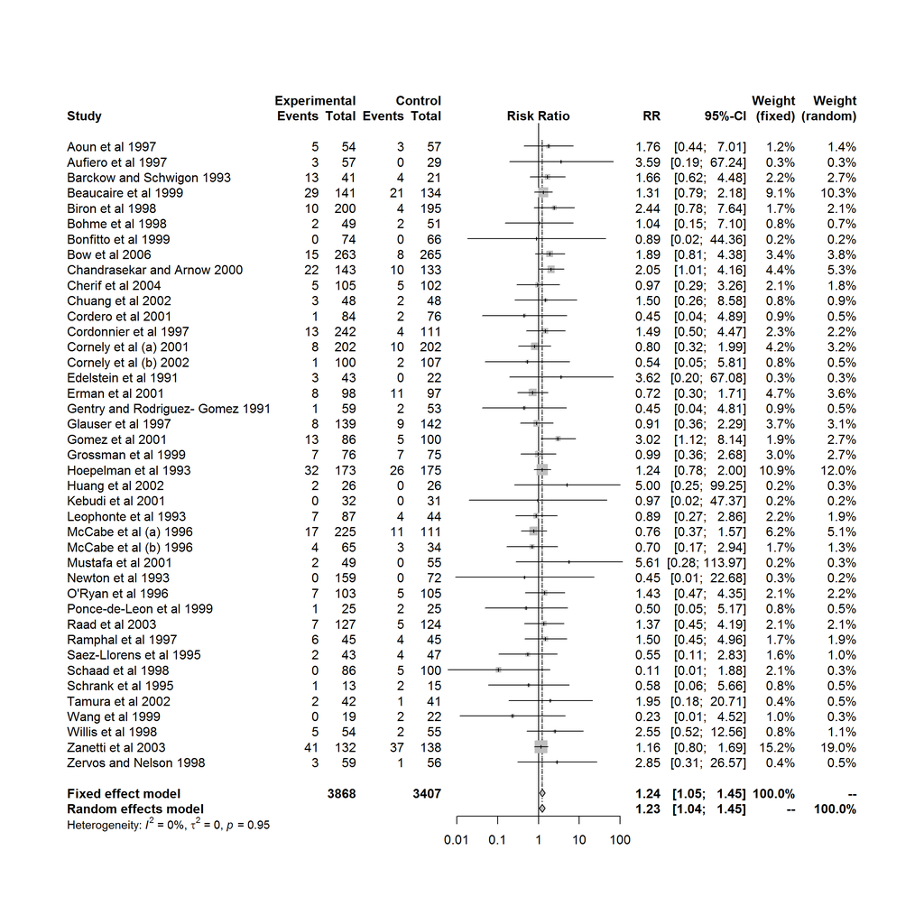

```r
# Read the file with studies
# Personalise visualisation
# settings.meta("revman5") # or "jama"

# Simple meta-analysis (ungrouped)
meta_basic <-  metabin(event.e = cefepime_events_fatal,
                       n.e = cefepime_total,
                       event.c = comparator_events_fatal,
                       n.c = comparator_total,
                       data = papers,
                       sm = "RR",
                       studlab = paste(author, year),
                       allstudies = TRUE,
                       title = "Meta-analysis of all-cause mortality with cefepime")

forest(meta_basic) # minimal code, arguments from metabin get passed
```

Before we go any further, we may want to consider using the Peto’s method, that does not require corrections for zero counts.

### Updating an analysis

Updating an analysis is simple, the `update` function needs only a few arguments. In this case, because we are changing the method to “Peto” the summary effect measure needs to change to “OR” as well.

```r
update(meta_basic, sm = "OR", method = "Peto")
```

```
## Review:     Meta-analysis of all-cause mortality with cefepime
##                                      OR             95%-CI %W(fixed)
## Aoun et al 1997                  1.8079 [0.4314;   7.5753]       1.6
## Aufiero et al 1997               4.6886 [0.4160;  52.8461]       0.6
## Barckow and Schwigon 1993        1.8699 [0.5807;   6.0212]       2.4
## Beaucaire et al 1999             1.3881 [0.7527;   2.5596]       8.9
## Biron et al 1998                 2.3640 [0.8146;   6.8606]       3.0
## Bohme et al 1998                 1.0421 [0.1423;   7.6295]       0.8
## Bonfitto et al 1999                  NA                          0.0
## Bow et al 2006                   1.9024 [0.8254;   4.3846]       4.8
## Chandrasekar and Arnow 2000      2.1482 [1.0289;   4.4851]       6.2
## Cherif et al 2004                0.9701 [0.2731;   3.4467]       2.1
## Chuang et al 2002                1.5183 [0.2532;   9.1043]       1.0
## Cordero et al 2001               0.4591 [0.0469;   4.4907]       0.6
## Cordonnier et al 1997            1.4691 [0.5152;   4.1895]       3.1
## Cornely et al (a) 2001           0.7929 [0.3085;   2.0382]       3.8
## Cornely et al (b) 2002           0.5457 [0.0561;   5.3119]       0.6
## Edelstein et al 1991             4.7607 [0.4192;  54.0588]       0.6
## Erman et al 2001                 0.6981 [0.2716;   1.7946]       3.8
## Gentry and Rodriguez- Gomez 1991 0.4537 [0.0461;   4.4676]       0.6
## Glauser et al 1997               0.9029 [0.3392;   2.4037]       3.5
## Gomez et al 2001                 3.1618 [1.1958;   8.3599]       3.5
## Grossman et al 1999              0.9856 [0.3293;   2.9498]       2.8
## Hoepelman et al 1993             1.2986 [0.7396;   2.2804]      10.6
## Huang et al 2002                 7.6906 [0.4680; 126.3920]       0.4
## Kebudi et al 2001                    NA                          0.0
## Leophonte et al 1993             0.8739 [0.2376;   3.2140]       2.0
## McCabe et al (a) 1996            0.7354 [0.3235;   1.6720]       5.0
## McCabe et al (b) 1996            0.6689 [0.1337;   3.3465]       1.3
## Mustafa et al 2001               8.5272 [0.5237; 138.8322]       0.4
## Newton et al 1993                    NA                          0.0
## O'Ryan et al 1996                1.4512 [0.4536;   4.6429]       2.5
## Ponce-de-Leon et al 1999         0.4991 [0.0495;   5.0318]       0.6
## Raad et al 2003                  1.3823 [0.4344;   4.3979]       2.5
## Ramphal et al 1997               1.5605 [0.4221;   5.7688]       2.0
## Saez-Llorens et al 1995          0.5415 [0.1041;   2.8165]       1.2
## Schaad et al 1998                0.1494 [0.0253;   0.8836]       1.1
## Schrank et al 1995               0.5663 [0.0536;   5.9856]       0.6
## Tamura et al 2002                1.9323 [0.1954;  19.1094]       0.6
## Wang et al 1999                  0.1479 [0.0089;   2.4676]       0.4
```

[output cut: 47 more lines]

```
##
##                          OR           95%-CI    z p-value
## Fixed effect model   1.2811 [1.0668; 1.5384] 2.65  0.0080
## Random effects model 1.2811 [1.0668; 1.5384] 2.65  0.0080
##
## Quantifying heterogeneity:
## tau^2 = 0; H = 1.00 [1.00; 1.14]; I^2 = 0.0% [0.0%; 23.7%]
##
## Test of heterogeneity:
##      Q d.f. p-value
##  33.64   40  0.7509
##
## Details on meta-analytical method:
## - Peto method
## - DerSimonian-Laird estimator for tau^2
```

### Heterogeneity

Intuitively, I would have expected the results to show some heterogeneity but the I2 statistic does not suggest this. Noticeably, there are biases in the calculation of the I2, thus diagnostics of heteregeneity and influence analyses should always be conducted.

Here we’ll use the full arsenal of methods: funnel, metabias, baujat, l’Abbé and radial plot.

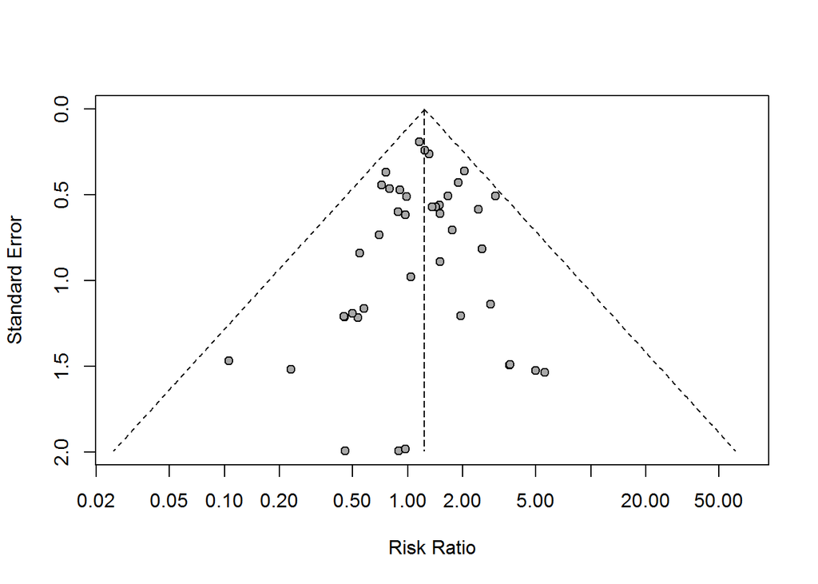

```r
funnel(meta_basic)
```

```r
metabias(meta_basic)
```

```
## Review:     Meta-analysis of all-cause mortality with cefepime
##
##  Linear regression test of funnel plot asymmetry
##
## data:  meta_basic
## t = -0.4991, df = 39, p-value = 0.6205
## alternative hypothesis: asymmetry in funnel plot
## sample estimates:
##       bias    se.bias      slope
## -0.1173673  0.2351591  0.2586715
```

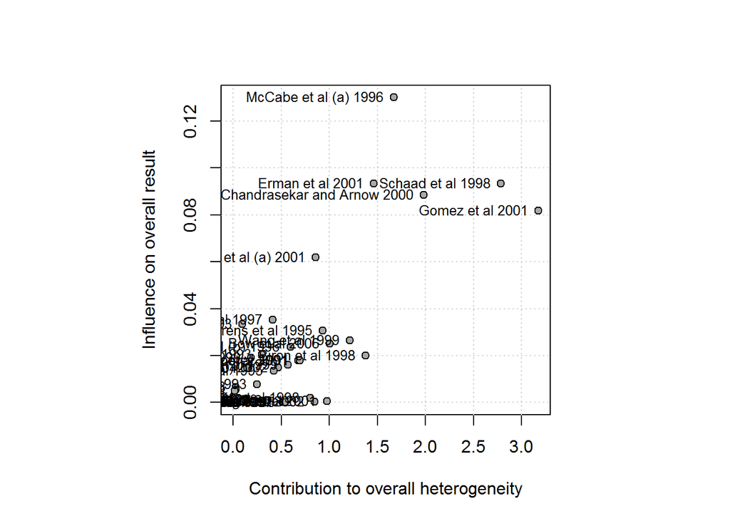

```r
baujat(meta_basic)
```

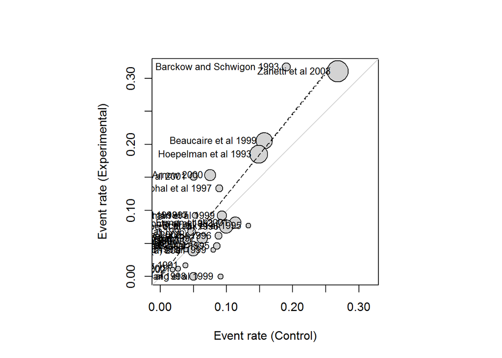

```r
labbe(meta_basic, studlab = TRUE)
```

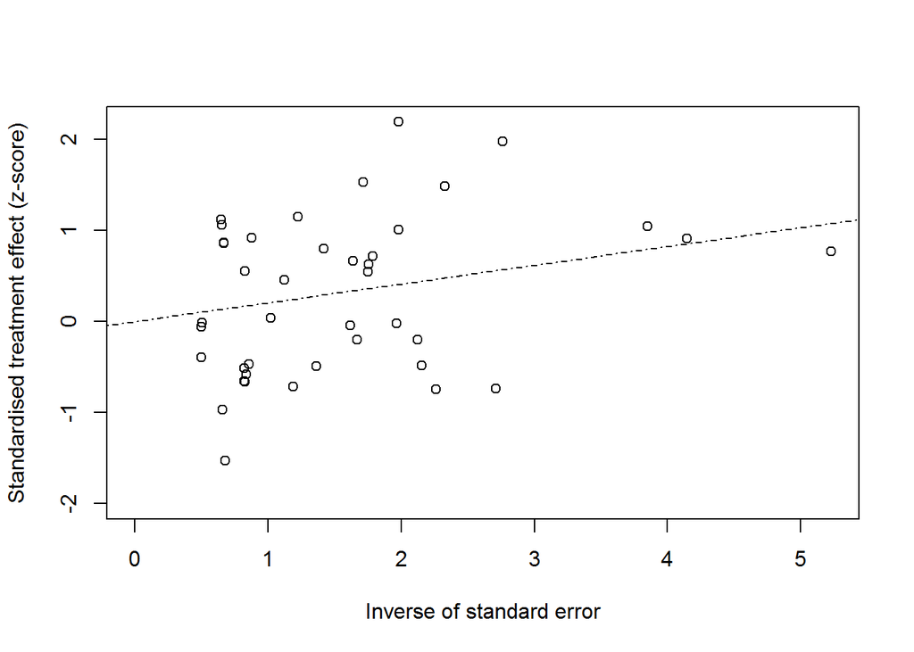

```r
radial.meta(meta_basic)
```

### Subgrouped meta-analysis

Subgrouping helps explain heterogeneity. In this case we have no indication of heterogeneity being a significant issue, but we can subgroup to understand the characteristics of the concern, i.e. where all-cause mortality is ocurring.

First we subgroup by indication. In `meta` we just pass a variable to the argument `byvar`.

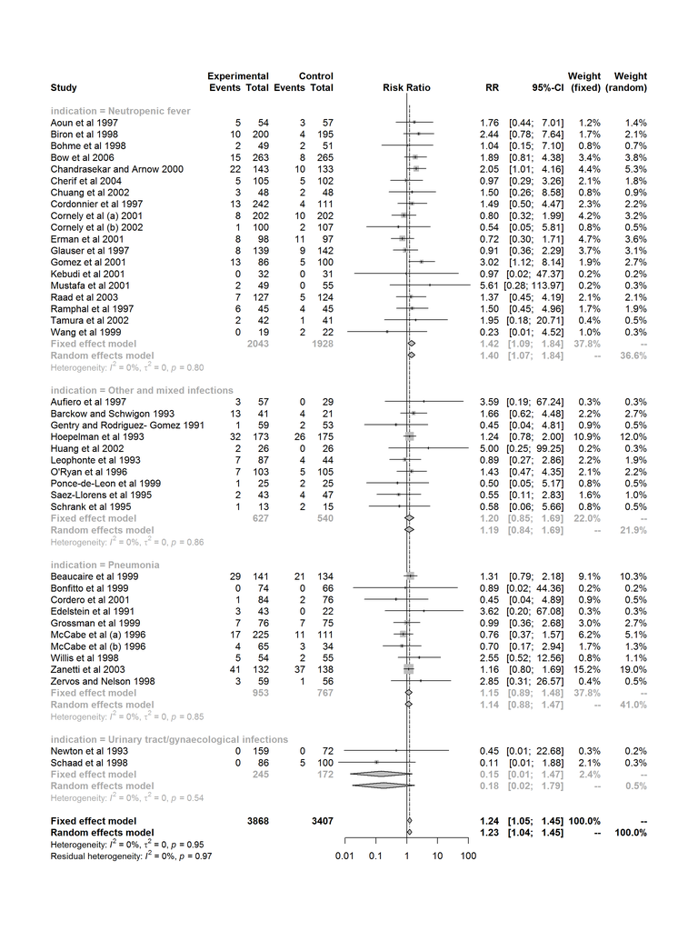

```r
# Meta-analysis subgrouped by indication
meta_indication <-  metabin(event.e = cefepime_events_fatal,
                       n.e = cefepime_total,
                       event.c = comparator_events_fatal,
                       n.c = comparator_total,
                       data = papers,
                       sm = "RR",
                       studlab = paste(author, year),
                       byvar = indication,
                       allstudies = TRUE,
                       title = "Meta-analysis of all-cause mortality with cefepime, subgrouped by indication")

forest(meta_indication)
```

We can then subgroup by comparator drug.

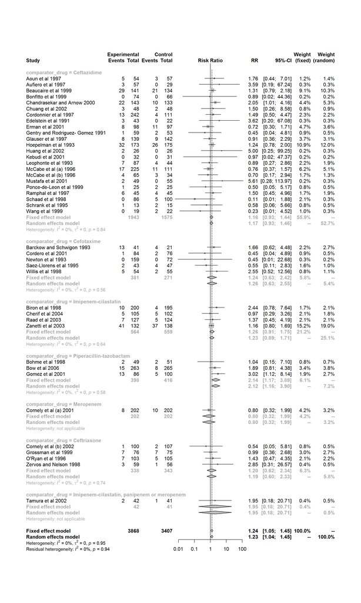

```r
# Meta-analysis subgrouped by comparator drug
meta_comparator <-  metabin(event.e = cefepime_events_fatal,
                       n.e = cefepime_total,
                       event.c = comparator_events_fatal,
                       n.c = comparator_total,
                       data = papers,
                       sm = "RR",
                       studlab = paste(author, year),
                       byvar = comparator_drug,
                       allstudies = TRUE,
                       title = "Meta-analysis of all-cause mortality with cefepime, subgrouped by comparator")
forest(meta_comparator)
```

And by severity of indication, which was extracted from the drug dose.

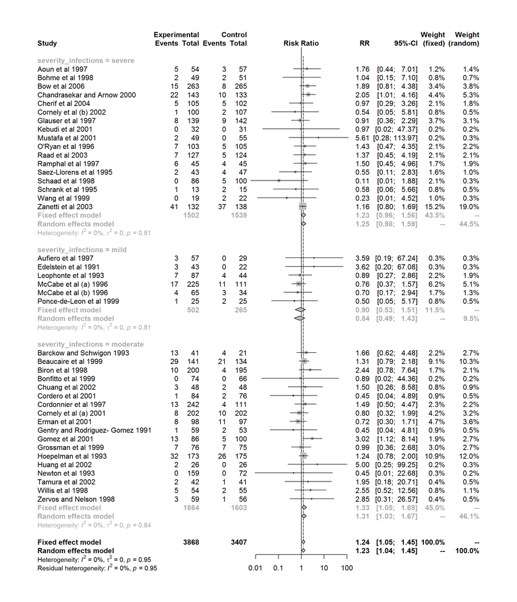

```r
# Meta-analysis subgrouped by severity
meta_severity <-  metabin(event.e = cefepime_events_fatal,
                       n.e = cefepime_total,
                       event.c = comparator_events_fatal,
                       n.c = comparator_total,
                       data = papers,
                       sm = "RR",
                       studlab = paste(author, year),
                       byvar = severity_infections,
                       allstudies = TRUE,
                       title = "Meta-analysis of all-cause mortality with cefepime, subgrouped by severity of infections")

forest(meta_severity)
```

### Sensitivity analyses

With `meta` we can run a cumulative meta-analysis and a leave-one-out meta-analysis as per below. Both functions have a `sortvar` function to reorder the studies. By default the ordering is the same as the order of the data frame. One interesting reordering criteria is by trial size. In this case, we would do `metainf(meta_basic, sortvar = cefepime_total + comparator_total)`.

```r
# cumulative meta-analysis
metacum(meta_basic)
```

```
## Review:     Meta-analysis of all-cause mortality with cefepime
##
## Cumulative meta-analysis (Fixed effect model)
##
##                                                      RR           95%-CI
## Adding Aoun et al 1997 (k=1)                     1.7593 [0.4417; 7.0077]
## Adding Aufiero et al 1997 (k=2)                  2.1021 [0.6015; 7.3467]
## Adding Barckow and Schwigon 1993 (k=3)           1.8412 [0.8453; 4.0104]
## Adding Beaucaire et al 1999 (k=4)                1.4666 [0.9582; 2.2449]
## Adding Biron et al 1998 (k=5)                    1.5808 [1.0613; 2.3546]
## Adding Bohme et al 1998 (k=6)                    1.5517 [1.0508; 2.2914]
## Adding Bonfitto et al 1999 (k=7)                 1.5423 [1.0466; 2.2728]
## Adding Bow et al 2006 (k=8)                      1.6039 [1.1277; 2.2810]
## Adding Chandrasekar and Arnow 2000 (k=9)         1.6868 [1.2308; 2.3117]
## Adding Cherif et al 2004 (k=10)                  1.6267 [1.1999; 2.2051]
## Adding Chuang et al 2002 (k=11)                  1.6226 [1.2024; 2.1897]
## Adding Cordero et al 2001 (k=12)                 1.5845 [1.1781; 2.1310]
## Adding Cordonnier et al 1997 (k=13)              1.5771 [1.1845; 2.0998]
## Adding Cornely et al (a) 2001 (k=14)             1.4799 [1.1278; 1.9419]
## Adding Cornely et al (b) 2002 (k=15)             1.4576 [1.1132; 1.9084]
## Adding Edelstein et al 1991 (k=16)               1.4751 [1.1280; 1.9290]
## Adding Erman et al 2001 (k=17)                   1.3859 [1.0740; 1.7884]
## Adding Gentry and Rodriguez- Gomez 1991 (k=18)   1.3652 [1.0600; 1.7583]
## Adding Glauser et al 1997 (k=19)                 1.3263 [1.0395; 1.6923]
## Adding Gomez et al 2001 (k=20)                   1.3982 [1.1048; 1.7694]
## Adding Grossman et al 1999 (k=21)                1.3732 [1.0921; 1.7267]
## Adding Hoepelman et al 1993 (k=22)               1.3499 [1.0983; 1.6591]
## Adding Huang et al 2002 (k=23)                   1.3627 [1.1095; 1.6737]
## Adding Kebudi et al 2001 (k=24)                  1.3613 [1.1087; 1.6715]
## Adding Leophonte et al 1993 (k=25)               1.3443 [1.0983; 1.6453]
## Adding McCabe et al (a) 1996 (k=26)              1.2917 [1.0638; 1.5685]
## Adding McCabe et al (b) 1996 (k=27)              1.2777 [1.0543; 1.5485]
## Adding Mustafa et al 2001 (k=28)                 1.2899 [1.0650; 1.5623]
## Adding Newton et al 1993 (k=29)                  1.2865 [1.0625; 1.5577]
## Adding O'Ryan et al 1996 (k=30)                  1.2905 [1.0688; 1.5583]
## Adding Ponce-de-Leon et al 1999 (k=31)           1.2815 [1.0621; 1.5462]
## Adding Raad et al 2003 (k=32)                    1.2839 [1.0668; 1.5451]
## Adding Ramphal et al 1997 (k=33)                 1.2886 [1.0731; 1.5473]
## Adding Saez-Llorens et al 1995 (k=34)            1.2735 [1.0619; 1.5272]
## Adding Schaad et al 1998 (k=35)                  1.2427 [1.0376; 1.4884]
```

[output cut: 40 more lines]

```
## Adding Raad et al 2003 (k=32)                     0.0082  0.0000  0.0%
## Adding Ramphal et al 1997 (k=33)                  0.0066  0.0000  0.0%
## Adding Saez-Llorens et al 1995 (k=34)             0.0091  0.0000  0.0%
## Adding Schaad et al 1998 (k=35)                   0.0183  0.0000  0.0%
## Adding Schrank et al 1995 (k=36)                  0.0207  0.0000  0.0%
## Adding Tamura et al 2002 (k=37)                   0.0186  0.0000  0.0%
## Adding Wang et al 1999 (k=38)                     0.0241  0.0000  0.0%
## Adding Willis et al 1998 (k=39)                   0.0169  0.0000  0.0%
## Adding Zanetti et al 2003 (k=40)                  0.0122  0.0000  0.0%
## Adding Zervos and Nelson 1998 (k=41)              0.0098  0.0000  0.0%
##
## Pooled estimate                                   0.0098  0.0000  0.0%
##
## Details on meta-analytical method:
## - Mantel-Haenszel method
```

```r
metainf(meta_basic)
```

```
## Review:     Meta-analysis of all-cause mortality with cefepime
##
## Influential analysis (Fixed effect model)
##
##                                                 RR           95%-CI
## Omitting Aoun et al 1997                    1.2291 [1.0457; 1.4447]
## Omitting Aufiero et al 1997                 1.2290 [1.0465; 1.4433]
## Omitting Barckow and Schwigon 1993          1.2258 [1.0418; 1.4424]
## Omitting Beaucaire et al 1999               1.2279 [1.0369; 1.4541]
## Omitting Biron et al 1998                   1.2147 [1.0328; 1.4287]
## Omitting Bohme et al 1998                   1.2372 [1.0532; 1.4534]
## Omitting Bonfitto et al 1999                1.2364 [1.0529; 1.4518]
## Omitting Bow et al 2006                     1.2129 [1.0299; 1.4285]
## Omitting Chandrasekar and Arnow 2000        1.1986 [1.0163; 1.4137]
## Omitting Cherif et al 2004                  1.2414 [1.0558; 1.4596]
## Omitting Chuang et al 2002                  1.2333 [1.0498; 1.4490]
## Omitting Cordero et al 2001                 1.2426 [1.0579; 1.4596]
## Omitting Cordonnier et al 1997              1.2296 [1.0455; 1.4461]
## Omitting Cornely et al (a) 2001             1.2547 [1.0658; 1.4771]
## Omitting Cornely et al (b) 2002             1.2413 [1.0568; 1.4581]
## Omitting Edelstein et al 1991               1.2289 [1.0464; 1.4432]
## Omitting Erman et al 2001                   1.2608 [1.0706; 1.4848]
## Omitting Gentry and Rodriguez- Gomez 1991   1.2426 [1.0579; 1.4596]
## Omitting Glauser et al 1997                 1.2483 [1.0606; 1.4694]
## Omitting Gomez et al 2001                   1.2001 [1.0195; 1.4127]
## Omitting Grossman et al 1999                1.2432 [1.0566; 1.4627]
## Omitting Hoepelman et al 1993               1.2344 [1.0409; 1.4640]
## Omitting Huang et al 2002                   1.2277 [1.0453; 1.4419]
## Omitting Kebudi et al 2001                  1.2362 [1.0527; 1.4515]
## Omitting Leophonte et al 1993               1.2436 [1.0576; 1.4624]
## Omitting McCabe et al (a) 1996              1.2669 [1.0743; 1.4939]
## Omitting McCabe et al (b) 1996              1.2447 [1.0590; 1.4629]
## Omitting Mustafa et al 2001                 1.2269 [1.0446; 1.4410]
## Omitting Newton et al 1993                  1.2379 [1.0541; 1.4536]
## Omitting O'Ryan et al 1996                  1.2315 [1.0472; 1.4483]
## Omitting Ponce-de-Leon et al 1999           1.2418 [1.0572; 1.4587]
## Omitting Raad et al 2003                    1.2327 [1.0482; 1.4497]
## Omitting Ramphal et al 1997                 1.2311 [1.0470; 1.4475]
## Omitting Saez-Llorens et al 1995            1.2469 [1.0610; 1.4652]
## Omitting Schaad et al 1998                  1.2603 [1.0725; 1.4810]
```

[output cut: 40 more lines]

```
## Omitting Raad et al 2003                     0.0114  0.0000  0.0%
## Omitting Ramphal et al 1997                  0.0119  0.0000  0.0%
## Omitting Saez-Llorens et al 1995             0.0074  0.0000  0.0%
## Omitting Schaad et al 1998                   0.0049  0.0000  0.0%
## Omitting Schrank et al 1995                  0.0086  0.0000  0.0%
## Omitting Tamura et al 2002                   0.0109  0.0000  0.0%
## Omitting Wang et al 1999                     0.0075  0.0000  0.0%
## Omitting Willis et al 1998                   0.0139  0.0000  0.0%
## Omitting Zanetti et al 2003                  0.0135  0.0000  0.0%
## Omitting Zervos and Nelson 1998              0.0122  0.0000  0.0%
##
## Pooled estimate                              0.0098  0.0000  0.0%
##
## Details on meta-analytical method:
## - Mantel-Haenszel method
```

### Meta-regression

Another functionality available in `meta` is a meta-regression. The meta-regression helps explain the results as a function of some explanatory variables. The simplest implementation of the `metareg` function takes a `meta` object and a formula `~ var_1 + var_2 + ... + var_n`.

```r
metareg(meta_basic, ~ as.factor(papers$indication) + as.factor(severity_infections) + as.factor(comparator_drug))
```

```
##
## Mixed-Effects Model (k = 41; tau^2 estimator: DL)
##
## tau^2 (estimated amount of residual heterogeneity):     0 (SE = 0.1135)
## tau (square root of estimated tau^2 value):             0
## I^2 (residual heterogeneity / unaccounted variability): 0.00%
## H^2 (unaccounted variability / sampling variability):   1.00
## R^2 (amount of heterogeneity accounted for):            0.00%
##
## Test for Residual Heterogeneity:
## QE(df = 29) = 17.1858, p-val = 0.9592
##
## Test of Moderators (coefficients 2:12):
## QM(df = 11) = 9.5843, p-val = 0.5681
##
## Model Results:
##
##                                                                        estimate
## intrcpt                                                                  0.0726
## as.factor(papers$indication)Other and mixed infections                  -0.1342
## as.factor(papers$indication)Pneumonia                                   -0.1542
## as.factor(papers$indication)Urinary tract/gynaecological infections     -2.0305
## as.factor(severity_infections)moderate                                   0.3917
## as.factor(severity_infections)severe                                     0.2284
## as.factor(comparator_drug)Ceftazidime                                   -0.0962
## as.factor(comparator_drug)Ceftriaxone                                   -0.0861
## as.factor(comparator_drug)Imipenem-cilastatin                            0.0120
## as.factor(comparator_drug)Imipenem-cilastatin, panipenem or meropenem    0.2047
## as.factor(comparator_drug)Meropenem                                     -0.6875
## as.factor(comparator_drug)Piperacillin-tazobactam                        0.3911
##                                                                            se
## intrcpt                                                                0.5645
## as.factor(papers$indication)Other and mixed infections                 0.2714
## as.factor(papers$indication)Pneumonia                                  0.2458
## as.factor(papers$indication)Urinary tract/gynaecological infections    1.2036
## as.factor(severity_infections)moderate                                 0.3197
## as.factor(severity_infections)severe                                   0.3730
## as.factor(comparator_drug)Ceftazidime                                  0.3963
## as.factor(comparator_drug)Ceftriaxone                                  0.5087
## as.factor(comparator_drug)Imipenem-cilastatin                          0.4557
```

[output cut: 56 more lines]

```
## intrcpt
## as.factor(papers$indication)Other and mixed infections
## as.factor(papers$indication)Pneumonia
## as.factor(papers$indication)Urinary tract/gynaecological infections    .
## as.factor(severity_infections)moderate
## as.factor(severity_infections)severe
## as.factor(comparator_drug)Ceftazidime
## as.factor(comparator_drug)Ceftriaxone
## as.factor(comparator_drug)Imipenem-cilastatin
## as.factor(comparator_drug)Imipenem-cilastatin, panipenem or meropenem
## as.factor(comparator_drug)Meropenem
## as.factor(comparator_drug)Piperacillin-tazobactam
##
## ---
## Signif. codes:  0 '***' 0.001 '**' 0.01 '*' 0.05 '.' 0.1 ' ' 1
```

## The `metafor` package

The `meta` and `metafor` packages are very similar in terms of functionalities. One significant difference is how these packages tackle subgroups. `meta` allows passing a variable to the `byvar` argument which gets plotted when calling forest plot. `metafor` has a different approach. Either multiple subsetted meta-analyses are conducted and plotted in the same plot or a `mods` variable can be passed to the meta-analysis.

### Basic meta-analysis with `metafor`

The arguments are less user friendly in `metafor`.

```r
library(metafor)
args(rma)
```

```
## function (yi, vi, sei, weights, ai, bi, ci, di, n1i, n2i, x1i,
##     x2i, t1i, t2i, m1i, m2i, sd1i, sd2i, xi, mi, ri, ti, sdi,
##     r2i, ni, mods, measure = "GEN", intercept = TRUE, data, slab,
##     subset, add = 1/2, to = "only0", drop00 = FALSE, vtype = "LS",
##     method = "REML", weighted = TRUE, test = "z", level = 95,
##     digits, btt, tau2, verbose = FALSE, control, ...)
## NULL
```

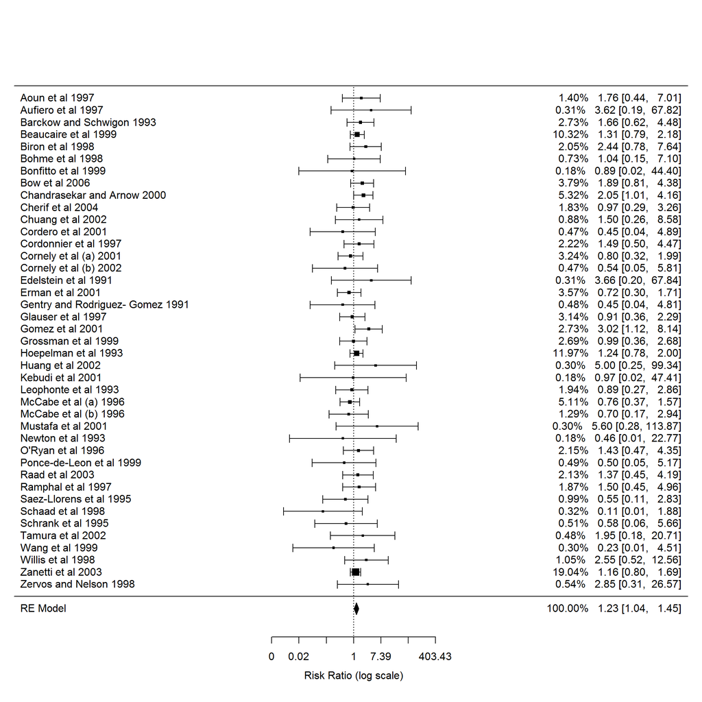

```r
metafor_basic <- metafor::rma(ai = cefepime_events_fatal,
             n1i = cefepime_total,
             ci = comparator_events_fatal,
             n2i = comparator_total,
             data = papers,
             measure = "RR",
             slab = paste(author, year))


metafor::forest(metafor_basic, showweights = T, atransf = exp)
```

The basic plot in `metafor` isn’t very appealing. Editing the plot in `metafor` is similar to the base graph in R: information is added stepwise, but the relative positions need to be defined.

### Heterogeneity and diagnostic plots with `metafor`

The diagnostic plots and plots detailing heterogeneity are however, much better.

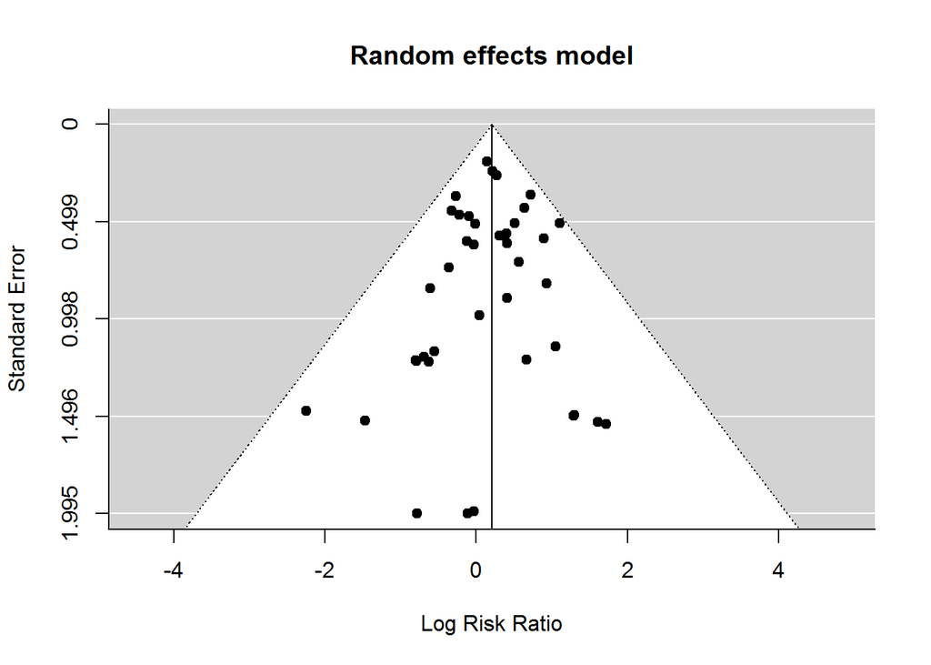

```r
metafor::funnel(metafor_basic, main = "Random effects model")
```

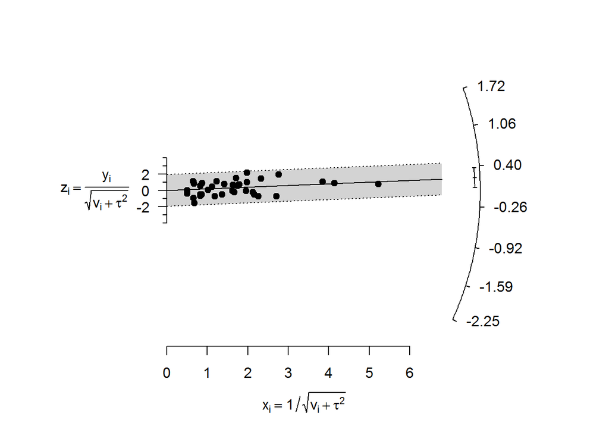

```r
metafor::radial(metafor_basic)
```